# A Tutorial to Matching

OPIM 5510 - Web Analytics, Instructor: [Xinxin Li](https://www.business.uconn.edu/person/xinxin-li/)

Last Updated: February 14, 2020

This tutorial uses an empirical example to describe matching strategies. The data source is used in a working paper written by:

[Hongfei Li](https://www.hongfei-business.com/) [Jing Peng](https://www.business.uconn.edu/person/jing-peng/) [Xinxin Li](https://www.business.uconn.edu/person/xinxin-li/) [Jan Stallaert](https://www.business.uconn.edu/person/jan-stallaert/)

All the data source and R codes can be found [here](https://github.com/HongfeiUconn/Matching_Tutorial).

## Import libraries

- All data filter and rearrangement are based on package [data.table](https://cran.r-project.org/web/packages/data.table/data.table.pdf).

```r
library(cem)
library(data.table)
library(MatchIt)
```

## Empirical Context

Our context is one of the largest online platforms for cosmetic procedures in China. It allows customers to make appointments for a cosmetic procedure offered by a specific hospital online by paying a certain amount of deposit. Then the customer goes offline to pay the rest of the price and take the surgery.

The platform offers a complication insurance policy, which aims at compensating customers for surgical malpractice or post-treatment complications such as severe infection. However, this insurance policy is only available for a subset of procedures. We are interested in whether the insurance has any effect on the average sales of procedures.

- The following image shows a procedure without insurance option.

[figure not shown]

- The following image shows a procedure with insurance option.

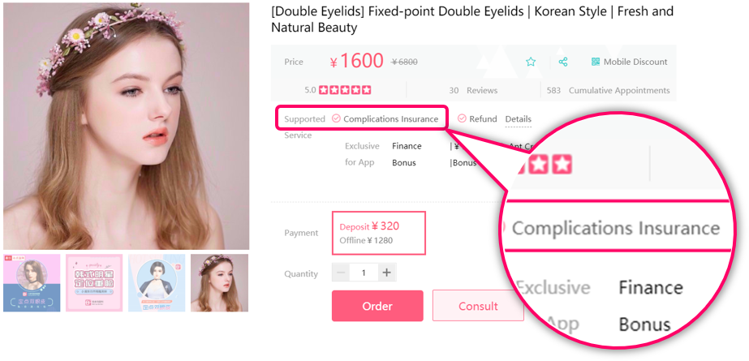

## Explore Data

### Read Data

```r
data = fread("data.csv")

colnames(data)
```

```
#>  [1] "ProcedureID"   "ProcedureAge"  "AvgCompNum"    "AvgReviews"
#>  [5] "PriceDeposit"  "PricePaid"     "PriceOrigin"   "Public"
#>  [9] "SurgeonNum"    "ReviewBonus"   "Ad"            "Financing"
#> [13] "GroupPurchase" "Insurance"     "AvgSales"
```

### Description of Variables

```r
## Read data fastly
description = fread("description.csv")
## Description of Variables
library(knitr)
kable(description, caption = "Description of Variables")
```

Description of Variables

| Variables | Description |
| --- | --- |
| ProcedureAge | The number of months since a procedure was first available when the complication insurance was introduced |
| AvgCompNum | Average monthly number of competitors |
| AvgReviews | Average monthly number of reviews |
| PriceDeposit | The amount of deposit for the procedure |
| PricePaid | The effective price for the procedure, net of discounts |
| PriceOrigin | The original price of the procedure |
| SurgeonNum | The number of surgeons available for the procedure |
| Public | Dummy. Whether this procedure is performed by a public hospital |
| ReviewBonus | Dummy. Whether the provider offers a bonus for users to write reviews |
| Ad | Dummy. Whether there is an ad on the webpage of this procedure |
| Financing | Dummy. Whether this procedure supports financing |
| GroupPurchase | Dummy. Whether this procedure supports group purchasing |

Here, AvgSales is the dependent (or outcome) variable and Insurance is the treatment variable. When Insurance equals to 0, it means this procedure is not offered the complication insurance option, 1 otherwise.

### Motivation

To answer the above question, one may first come up with simple linear regression.

```r
## Simple linear regression
slr_no_match = lm(AvgSales~Insurance, data = data)
## Output the regression results

kable(summary(slr_no_match)$coefficients, caption = "Simple Linear Regression without Matching")
```

Simple Linear Regression without Matching

|  | Estimate | Std. Error | t value | Pr(>\|t\|) |
| --- | --- | --- | --- | --- |
| (Intercept) | 1.745647 | 0.2499938 | 6.982761 | 0e+00 |
| Insurance | 1.796752 | 0.3600070 | 4.990881 | 7e-07 |

From the above results, the effect of insurance is significantly positive. Next, we use multiple linear regression, which is more robust than simple linear regression.

```r
## Multiple linear regression
mlr_no_match = lm(AvgSales~Insurance + ProcedureAge + AvgCompNum + AvgReviews + PriceDeposit + PricePaid + PriceOrigin + Public + SurgeonNum + ReviewBonus + Ad + Financing + GroupPurchase, data = data)
## Output the regression results
kable(summary(mlr_no_match)$coefficients, caption = "Multiple Linear Regression without Matching")
```

Multiple Linear Regression without Matching

|  | Estimate | Std. Error | t value | Pr(>\|t\|) |
| --- | --- | --- | --- | --- |
| (Intercept) | -0.3290385 | 0.5731808 | -0.5740570 | 0.5660280 |
| Insurance | 0.5401356 | 0.3676441 | 1.4691806 | 0.1420245 |
| ProcedureAge | -0.0382136 | 0.0346189 | -1.1038372 | 0.2698670 |
| AvgCompNum | 0.2527672 | 0.0433001 | 5.8375623 | 0.0000000 |
| AvgReviews | 2.7419115 | 0.2252522 | 12.1726267 | 0.0000000 |
| PriceDeposit | -0.0006512 | 0.0002178 | -2.9898632 | 0.0028432 |
| PricePaid | 0.0000083 | 0.0000330 | 0.2513723 | 0.8015658 |
| PriceOrigin | 0.0000074 | 0.0000187 | 0.3970773 | 0.6913753 |
| Public | 0.0234518 | 0.7856962 | 0.0298485 | 0.9761924 |
| SurgeonNum | 0.2500097 | 0.3052465 | 0.8190420 | 0.4129117 |
| ReviewBonus | -0.6196929 | 3.4904615 | -0.1775390 | 0.8591126 |
| Ad | 0.8923829 | 0.6151730 | 1.4506210 | 0.1471254 |
| Financing | 1.2505170 | 0.4258077 | 2.9368118 | 0.0033741 |
| GroupPurchase | 1.3012623 | 0.5307413 | 2.4517826 | 0.0143452 |

From the above results, the effect of insurance is not significant anymore after controlling for all the covariates.

### Why do we want to use matching?

Suppose in an ideal situation, one procedure is insured and uninsured at the same time, then if we take the difference of the average monthly sales under the insured and uninsured situations, we can get a precise measurement of the impact of the insurance policy. However, one procedure can either be insured or uninsured, but it can never be in these two situations simultaneously, unless we have a parallel universe (which is called “counterfactual” in the literature of causal inference). To solve this issue, we may have the following two options:

- For each insured procedure, find an uninsured procedure which is exactly same with this insured procedure in terms of all characteristics such as the procedure type, price, hospital, number of reviews, etc. In this situation, although the two procedures are “two” procedures, they can still be treated as the same one since there are no difference between them except for whether they are insured, just like a comparison between twins. It can be shown that the bias of the estimation of the effect of insurance is designed to be 0 in this situation. Coarsened exact matching (CEM) refers to this idea.
- For each insured procedure, suppose the probability of this procedure is chosen to the insured group is $p$, we need find an uninsured procedure whose probability of this procedure is chosen to the insured group is also $p$. For example, flipping a fair coin to randomly assign the procedures into the insured or uninsured group. This means each procedure is equally likely to be assigned the insurance policy with probability 0.5. You can also use random number or toll a die to assign the procedures into the insured and uninsured groups, as long as you can guarantee a pair of procedures have the same chance to be assigned with the insurance. But in real world, we cannot assign the insurance by ourselves because everything has already been determined by the company. The only data we can use is observational but not experimental. However, if we happen to find two procedures—one insured and the other one uninsured—with the same probability to be assigned the insurance, we can solve the problem! This is the basic idea of propensity score matching. Then comparing the difference between their average monthly sales is an unbiased estimator of the effect of the insurance policy. It can be shown that the expectation of the bias of the estimation of the effect of insurance is 0. When the sample size is large enough, the bias becomes very close to 0 by law of large number.